# (pmxhelpr) Function Friday

`plot_dvtime()` is a convenience wrapper around `ggplot` for visualization of a continuous dependent variable (*DV*) over time (*TIME*). The function accepts NONMEM-format datasets directly with internal processing (e.g., BLQ handling, summary statistics, dose-normalization) to ensure consistency in exploratory analyses of PK/PD data.

The function is optimized for datasets containing a nominal time variable (*NTIME*), representing protocol-specified times of sample collection. This variable is used to bin data for calculation of summary statistics specified by the `cent` argument. Options include:

- `"none"`: No central tendency layer
- `"mean"`: Mean after axis transformation (default).
- `"mean_sdl"`: Mean +/- one standard deviation after axis transformation
- `"mean_sdl_upper"`: Mean + one standard deviation after axis transformation
- `"median"`: Median (50th percentile)
- `"median_iqr"`: Median +/- one quartile (inter-quartile range: 25th to 75h percentiles)
- `"median_iqr_upper"`: Median + one quartile

One may want to visualize only the mean +/- standard devation without the added visual noise of the data points. This can be accomplished by removing the points using *theme*.

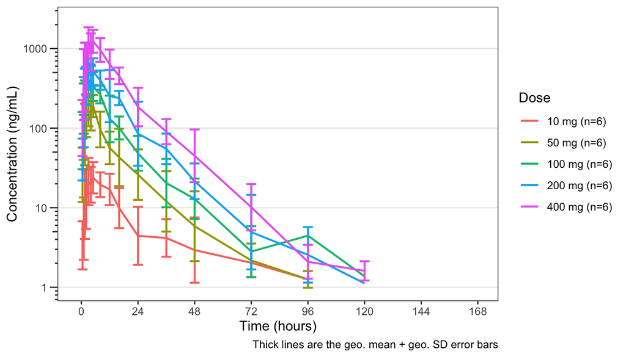

```r
plot_dvtime(data = plot_data, col_var = "Dose", cent = "mean_sdl",
            log_y = TRUE,
            theme = plot_dvtime_theme(obs_point = pmx_point(alpha = 0))) +
  scale_x_continuous(breaks = seq(0, 168, 24)) +
  labs(y = "Concentration (ng/mL)", x = "Time (hours)")
```

On the linear scale, the lower standard deviation error bar may cross the zero threshold, depending on the variability in the underlying data.

The `"mean_sdl_upper"` option exists to handle this scenario. Because the value of concentration cannot cross zero, we can suppress the lower error bars and visualize only the upper error bar to reduce visuale noise.

Let’s take a look at the outputs of `cent = "mean_sdl"` and `cent = "mean_sdl_upper"` side-by-side. We will suppress the captions in favor of titles, and gather our identical legends together in the bottom of the plot using `patchwork::plot_layout()` and `ggplot::theme()`.

```r
plot_sdl <-
  plot_dvtime(data = plot_data, col_var = "Dose", cent = "mean_sdl",
              show_caption = FALSE,
              theme = plot_dvtime_theme(obs_point = pmx_point(alpha = 0))) +
  scale_x_continuous(breaks = seq(0, 168, 24)) +
  labs(y = "Concentration (ng/mL)", x = "Time (hours)", title = "Mean +/- SD")
```

```r
plot_sdl_upper <-
  plot_dvtime(data = plot_data, col_var = "Dose", cent = "mean_sdl_upper",
              show_caption = FALSE,
              theme = plot_dvtime_theme(obs_point = pmx_point(alpha = 0))) +
  scale_x_continuous(breaks = seq(0, 168, 24)) +
  labs(y = "Concentration (ng/mL)", x = "Time (hours)", title = "Mean + SD")
```

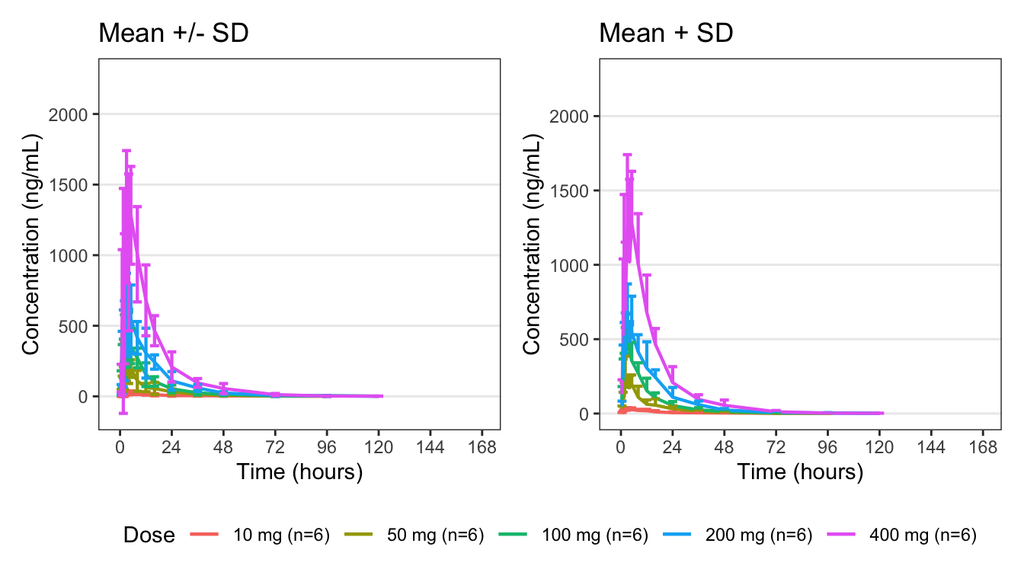

```r
plot_sdl + plot_sdl_upper + plot_layout(guides = "collect") & theme(legend.position = "bottom")
```

Perhaps we want to visualize central tendency and individual trends without making any distributional assumptions. The non-parametric central tendency measure requested with `cent = "median"`.

We can specify an additional argument `id_var`, which denotes the identifier variable in `data`. This argument may be passed as a bare name or a string. When `id_var` is specified, it is passed to the *group* aesthetic in `ggplot` and used to connect longitudinal repeated measures within an individual (e.g., spaghetti plots).

```r
plot_med_id <-
  plot_dvtime(data = plot_data, col_var = "Dose", cent = "median", id_var = ID,
            log_y = TRUE, show_caption = FALSE,
            theme = plot_dvtime_theme(obs_point = pmx_point(alpha = 0))) +
  scale_x_continuous(breaks = seq(0, 168, 24)) +
  labs(y = "Concentration (ng/mL)", x = "Time (hours)", title = "Median (Individual)")
```

```r
plot_id <-
  plot_dvtime(data = plot_data, col_var = "Dose", cent = "none", id_var = ID,
            log_y = TRUE, show_caption = FALSE,
            theme = plot_dvtime_theme(obs_point = pmx_point(alpha = 0))) +
  scale_x_continuous(breaks = seq(0, 168, 24)) +
  labs(y = "Concentration (ng/mL)", x = "Time (hours)", title = "Individual") +
  theme(legend.position = "none")
```

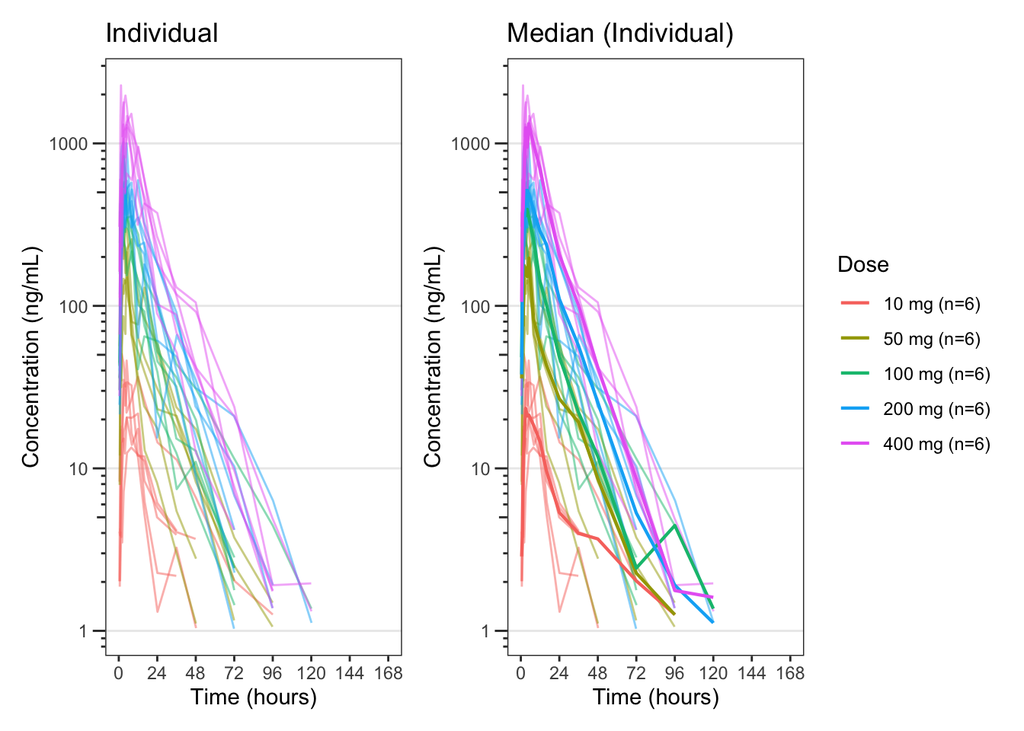

```r
plot_id + plot_med_id + plot_layout(guides = "collect")
```